# CRIC_AOR_CC

Zihe Zheng

December 1, 2018

### Overview

##### Discovery of CKD patient subtypes with differential risk profiles is essential for improving health promotion strategies and precision medicine approaches in the prevention and treatment of kidney function decline and prediction of clinical outcomes. Using baseline data from the Chronic Renal Insufficiency Cohort (CRIC) Study, including demographic, clinical history, kidney function, anthropometric/ nutritional, functional scores, vascular, medication usage, together with novel biochemical markers, we aim to create CKD subtypes with unsupervised cluster analysis algorithms.

### Introduction

##### Chronic kidney disease (CKD) affects approximately 15% of adults in the United States and is a major cause of end-stage-renal-disease (ESRD), cardiovascular disease (CVD), morbidity, and mortality. The estimated crude U.S. prevalence rate of stage 3 and 4 CKD was 7.0% in 2011-14, along with higher percentage of symptomatic and asymptomatic stage 1 and 2 CKD. The goal of CKD treatment and management is to delay disease progression, and minimize and prevent complications. Thus, it is important to address the heterogenity within CKD population and to identify the unobservable patient subgroups featured with different risk factor profiles. Discovery of the unique clusters among people with CKD will potentially provide insights to outcome prognosis, disease pathophysiology, and prevention strategies.

##### Revealing the latent clusters within CKD patients is an interdisciplinary research question that requires input from both renal pathophysiology and bioinformatics. CKD subgroups are traditionally based on the two common existing kidney markers of estimated glomerular filtration rate (eGFR) and microalbuminuria, which classifies patients on their impaired kidney function. However, patients with the same impaired kidney function does not necessarily have the same contributing disease pathophysioloy. Thus, the use of high-dimensional data, including risk factors and early disease biomarkers, with machine learnign algorithm will allow us to construct meaningful patients clusters that discriminate disease risks and add more information to the existing patients classification. Also, the data-driven consensus clustering approach makes less assumption about the data and is hypothesis free, which is more flexible to use with complex data structure.

### Methods

##### This study used the existing data from the Chronic Renal Insufficiency Cohort (CRIC) Study, an NIDDK-funded, multi-center, longitudinal cohort of well-characterized 5,499 men and women with CKD in the U.S. By design, participants were in the age range of 21-74 years, with eGFR of 20-70 ml/min/1.73m2 at study entry. CRIC study recruited participants in two phases from seven clinical centers from 2003 to 2008 (Phase I, N=3,939), and from 2013 to 2015 (Phase III, N=1,560). Subjects in this study are from CRIC Phase I cohort.

##### Set working directory, load the data

```r
setwd("C:/Users/zihez/Box Sync/DissertationResearch/CRIC metabolomics")
mydata <- read.csv("./Data/R/obesity_subgroup_1800_wmissing_slim.csv")
```

##### Correct the variable types

```r
mydata[mydata==""]<-NA
mydata$acearb<-factor(mydata$acearb)
mydata$antidiabetes<-factor(mydata$antidiabetes)
mydata$any_hvy<-factor(mydata$any_hvy)
mydata$betablk<-factor(mydata$betablk)
mydata$cablk<-factor(mydata$cablk)
mydata$diuretic<-factor(mydata$diuretic)
```

##### Make table 1 (with missing data)

```r
library(tableone)
mydatatable1<-mydata
mydatatable1$group<-"WithMissing"
table1var <- c("acearb", "age_integer", "alcoh_use", "antidiabetes", "any_hvy", "anycvd", "betablk",
               "cablk", "co2", "c_peptide", "cal_prot", "diastolic", "diuretic", "egfr_cric",
               "fgf23_calibrated", "food_energ", "hdl", "glucose", "height", "hemoglobin_a1c", "homa_ir",
               "hs_crp", "ldl", "nt_probnp",  "race_cat_1", "sa_allc_cric_renal1",
               "sa_allc_cric_time_renal1", "sa_allc_esrd", "sa_allc_time_esrd","sa_cvdcomp3b",
               "sa_death", "serum_urea_nitrogen", "female", "smokenow", "systolic", "time_cvdcomp3b",
               "time_death", "tnf_alpha", "tnths", "total_pth_calibrated", "troponini", "urine_albumin",
               "weight", "bmi", "waist")

vartoFactor <- c("female","race_cat_1","smokenow", "alcoh_use", "anycvd",
                "diuretic","acearb","betablk", "cablk", "antidiabetes", "any_hvy", "sa_allc_cric_renal1",
                "sa_allc_esrd", "sa_cvdcomp3b", "sa_death")
mydatatable1[vartoFactor]<-lapply(mydatatable1[vartoFactor], factor)

nonnormalVar<-c("hemoglobin_a1c", "serum_urea_nitrogen", "c_peptide", "fgf23_calibrated","food_energ",
                "glucose", "hs_crp", "nt_probnp",  "tnf_alpha", "tnths", "total_pth_calibrated",
                "troponini", "urine_albumin")
tableOne.miss <- CreateTableOne(vars=table1var,  data=mydatatable1)
print(tableOne.miss, nonnormal=nonnormalVar, contDigits = 2, catDigits = 2, pDigits = 4, missing=TRUE)
```

```
##
##                                        Overall                    Missing
##   n                                       1800
##   acearb = Yes (%)                        1235 (69.03)             0.6
##   age_integer (mean (sd))                57.60 (10.90)             0.0
##   alcoh_use = Yes (%)                     1165 (64.72)             0.0
##   antidiabetes = Yes (%)                   499 (27.89)             0.6
##   any_hvy = Yes (%)                        457 (25.49)             0.4
##   anycvd = Yes (%)                         598 (33.22)             0.0
##   betablk = Yes (%)                        880 (49.19)             0.6
##   cablk = Yes (%)                          711 (39.74)             0.6
##   co2 (mean (sd))                        24.50 (3.22)              0.7
##   c_peptide (median [IQR])                2.80 [1.81, 4.12]        1.7
##   cal_prot (mean (sd))                  285.80 (140.70)           23.7
##   diastolic (mean (sd))                  71.40 (12.89)             0.0
##   diuretic = Yes (%)                      1054 (58.92)             0.6
##   egfr_cric (mean (sd))                  45.62 (16.97)             0.0
##   fgf23_calibrated (median [IQR])       137.36 [93.87, 222.92]     0.7
##   food_energ (median [IQR])            1677.37 [1216.70, 2298.55] 23.7
##   hdl (mean (sd))                        47.73 (15.47)             0.1
##   glucose (median [IQR])                 97.00 [86.00, 124.00]     0.8
##   height (mean (sd))                    169.15 (9.54)              0.2
##   hemoglobin_a1c (median [IQR])           6.10 [5.60, 7.30]        1.5
##   homa_ir (mean (sd))                     6.40 (7.51)              6.1
##   hs_crp (median [IQR])                   2.54 [1.00, 6.32]        0.1
##   ldl (mean (sd))                       102.75 (35.70)             0.2
##   nt_probnp (median [IQR])              143.60 [60.12, 388.63]     2.2
##   race_cat_1 (%)                                                   0.0
##      Black                                 748 (41.56)
##      Others                                182 (10.11)
##      White                                 870 (48.33)
##   sa_allc_cric_renal1 = Yes (%)            643 (35.72)             0.0
##   sa_allc_cric_time_renal1 (mean (sd))    6.44 (3.56)              0.0
##   sa_allc_esrd = Yes (%)                   488 (27.11)             0.0
##   sa_allc_time_esrd (mean (sd))           7.90 (3.30)              0.0
##   sa_cvdcomp3b = Yes (%)                   310 (17.22)             0.0
##   sa_death = Yes (%)                       476 (26.44)             0.0
##   serum_urea_nitrogen (median [IQR])     26.00 [20.00, 36.00]      0.6
##   female = Yes (%)                         793 (44.06)             0.0
##   smokenow = Yes (%)                       218 (12.11)             0.0
##   systolic (mean (sd))                  127.59 (22.08)             0.0
##   time_cvdcomp3b (mean (sd))              8.03 (3.24)              0.0
##   time_death (mean (sd))                  9.06 (2.62)              0.0
##   tnf_alpha (median [IQR])                2.20 [1.50, 3.20]        0.7
##   tnths (median [IQR])                   11.65 [5.54, 22.48]       1.9
##   total_pth_calibrated (median [IQR])    54.00 [34.00, 86.85]      1.3
##   troponini (median [IQR])                0.00 [0.00, 0.01]        1.4
##   urine_albumin (median [IQR])           32.65 [6.10, 251.08]      2.9
##   weight (mean (sd))                     91.96 (23.15)             0.3
##   bmi (mean (sd))                        32.12 (7.69)              0.3
##   waist (mean (sd))                     106.18 (17.47)             1.4
```

##### Make table 1 (complete case)

```r
mydatatable1.comp<-na.omit(data.frame(mydata))
mydatatable1.comp$group<-"Complete"
tableOne.comp <- CreateTableOne(vars=table1var,  data=mydatatable1.comp)
print(tableOne.comp, nonnormal=nonnormalVar, contDigits = 2, catDigits = 2, pDigits = 4)
```

```
##
##                                        Overall
##   n                                       1174
##   acearb = Yes (%)                         806 (68.65)
##   age_integer (mean (sd))                57.82 (10.75)
##   alcoh_use = Yes (%)                      781 (66.52)
##   antidiabetes = Yes (%)                   319 (27.17)
##   any_hvy = Yes (%)                        304 (25.89)
##   anycvd = Yes (%)                         378 (32.20)
##   betablk = Yes (%)                        567 (48.30)
##   cablk = Yes (%)                          469 (39.95)
##   co2 (mean (sd))                        24.69 (3.13)
##   c_peptide (median [IQR])                2.80 [1.80, 4.04]
##   cal_prot (mean (sd))                  285.08 (139.39)
##   diastolic (mean (sd))                  70.92 (12.33)
##   diuretic = Yes (%)                       683 (58.18)
##   egfr_cric (mean (sd))                  46.57 (16.92)
##   fgf23_calibrated (median [IQR])       133.62 [90.62, 217.77]
##   food_energ (median [IQR])            1669.03 [1219.97, 2275.19]
##   hdl (mean (sd))                        48.64 (15.56)
##   glucose (median [IQR])                 96.00 [86.00, 120.00]
##   height (mean (sd))                    169.02 (9.48)
##   hemoglobin_a1c (median [IQR])           6.05 [5.60, 7.10]
##   homa_ir (mean (sd))                     6.23 (7.53)
##   hs_crp (median [IQR])                   2.52 [1.02, 6.19]
##   ldl (mean (sd))                       102.13 (34.22)
##   nt_probnp (median [IQR])              137.10 [59.18, 352.02]
##   race_cat_1 (%)
##      Black                                 481 (40.97)
##      Others                                 51 ( 4.34)
##      White                                 642 (54.68)
##   sa_allc_cric_renal1 = Yes (%)            401 (34.16)
##   sa_allc_cric_time_renal1 (mean (sd))    6.77 (3.53)
##   sa_allc_esrd = Yes (%)                   294 (25.04)
##   sa_allc_time_esrd (mean (sd))           8.27 (3.19)
##   sa_cvdcomp3b = Yes (%)                   191 (16.27)
##   sa_death = Yes (%)                       281 (23.94)
##   serum_urea_nitrogen (median [IQR])     25.50 [19.00, 34.00]
##   female = Yes (%)                         573 (48.81)
##   smokenow = Yes (%)                       143 (12.18)
##   systolic (mean (sd))                  125.78 (21.32)
##   time_cvdcomp3b (mean (sd))              8.31 (3.19)
##   time_death (mean (sd))                  9.37 (2.50)
##   tnf_alpha (median [IQR])                2.10 [1.40, 3.00]
##   tnths (median [IQR])                   10.49 [5.05, 19.41]
##   total_pth_calibrated (median [IQR])    52.60 [33.00, 83.00]
##   troponini (median [IQR])                0.00 [0.00, 0.01]
##   urine_albumin (median [IQR])           24.80 [5.12, 190.93]
##   weight (mean (sd))                     91.93 (23.06)
##   bmi (mean (sd))                        32.18 (7.81)
##   waist (mean (sd))                     106.18 (17.34)
```

##### Test for missing data mechanism

###### Comparing individuals with and without missing data, we found that missing data is dependent on covariates of race, survival time of CKD progression, ESRD, CVD and death, serum urea nitrogen, female gender, systolic blood pressue, TNF-alpha, troponin I, and urine albumin. The missing data mechanism is likely to be missing at random. Using complete case analysis will generate biased results. Thus, it is important to impute the missing data.

```r
comb.mydata<-rbind(mydatatable1, mydatatable1.comp)
comb.mydata$group<-as.factor(comb.mydata$group)
tableOne.md <- CreateTableOne(vars=table1var, strata="group", data=comb.mydata)
print(tableOne.md, nonnormal=nonnormalVar, contDigits = 2, catDigits = 2, pDigits = 4)
```

```
##                                       Stratified by group
##                                        Complete
##   n                                       1174
##   acearb = Yes (%)                         806 (68.65)
##   age_integer (mean (sd))                57.82 (10.75)
##   alcoh_use = Yes (%)                      781 (66.52)
##   antidiabetes = Yes (%)                   319 (27.17)
##   any_hvy = Yes (%)                        304 (25.89)
##   anycvd = Yes (%)                         378 (32.20)
##   betablk = Yes (%)                        567 (48.30)
##   cablk = Yes (%)                          469 (39.95)
##   co2 (mean (sd))                        24.69 (3.13)
##   c_peptide (median [IQR])                2.80 [1.80, 4.04]
##   cal_prot (mean (sd))                  285.08 (139.39)
##   diastolic (mean (sd))                  70.92 (12.33)
##   diuretic = Yes (%)                       683 (58.18)
##   egfr_cric (mean (sd))                  46.57 (16.92)
##   fgf23_calibrated (median [IQR])       133.62 [90.62, 217.77]
##   food_energ (median [IQR])            1669.03 [1219.97, 2275.19]
##   hdl (mean (sd))                        48.64 (15.56)
##   glucose (median [IQR])                 96.00 [86.00, 120.00]
##   height (mean (sd))                    169.02 (9.48)
##   hemoglobin_a1c (median [IQR])           6.05 [5.60, 7.10]
##   homa_ir (mean (sd))                     6.23 (7.53)
##   hs_crp (median [IQR])                   2.52 [1.02, 6.19]
##   ldl (mean (sd))                       102.13 (34.22)
##   nt_probnp (median [IQR])              137.10 [59.18, 352.02]
##   race_cat_1 (%)
##      Black                                 481 (40.97)
##      Others                                 51 ( 4.34)
##      White                                 642 (54.68)
##   sa_allc_cric_renal1 = Yes (%)            401 (34.16)
##   sa_allc_cric_time_renal1 (mean (sd))    6.77 (3.53)
##   sa_allc_esrd = Yes (%)                   294 (25.04)
##   sa_allc_time_esrd (mean (sd))           8.27 (3.19)
##   sa_cvdcomp3b = Yes (%)                   191 (16.27)
##   sa_death = Yes (%)                       281 (23.94)
##   serum_urea_nitrogen (median [IQR])     25.50 [19.00, 34.00]
##   female = Yes (%)                         573 (48.81)
##   smokenow = Yes (%)                       143 (12.18)
```

[output cut: 98 more lines]

```
##   sa_death = Yes (%)
##   serum_urea_nitrogen (median [IQR])   nonnorm
##   female = Yes (%)
##   smokenow = Yes (%)
##   systolic (mean (sd))
##   time_cvdcomp3b (mean (sd))
##   time_death (mean (sd))
##   tnf_alpha (median [IQR])             nonnorm
##   tnths (median [IQR])                 nonnorm
##   total_pth_calibrated (median [IQR])  nonnorm
##   troponini (median [IQR])             nonnorm
##   urine_albumin (median [IQR])         nonnorm
##   weight (mean (sd))
##   bmi (mean (sd))
##   waist (mean (sd))
```

##### Missing Data imputation

```r
library("Hmisc")
impute_arg <- aregImpute(~ pid+weight+height+waist+egfr_cric+urine_albumin+systolic+diastolic+
                           glucose+hemoglobin_a1c+homa_ir+food_energ+cal_prot+bmi+
                           antidiabetes+acearb+cablk+betablk+diuretic+
                           age_integer+female+race_cat_1+anycvd+smokenow+alcoh_use+any_hvy+
                           tnths+troponini+total_pth_calibrated+fgf23_calibrated+nt_probnp+co2+
                           serum_urea_nitrogen+hs_crp+c_peptide+ldl+hdl+tnf_alpha +
                           sa_allc_cric_renal1+sa_allc_cric_time_renal1+sa_allc_esrd+
                           sa_allc_time_esrd+sa_cvdcomp3b+time_cvdcomp3b+sa_death+time_death
                           , data = mydata, n.impute = 5, nk=4)
```

```
## Iteration 1
Iteration 2
Iteration 3
Iteration 4
Iteration 5
Iteration 6
Iteration 7
Iteration 8
```

##### Select one imputed dataset

```r
fill_data <- function(impute = impute_arg, data = mydata, im = 1) {
  cbind.data.frame(impute.transcan(x = impute,
                                   imputation = im,
                                   data = data,
                                   list.out = TRUE,
                                   pr = FALSE))
}
fulldata <- as.data.frame(fill_data(im = 3))
write.csv(fulldata, file = "C:/Users/zihez/Documents/Research/local_save/obesity_subgroup_1800_impute_slim.csv")

save(fulldata, file="C:/Users/zihez/Documents/Research/local_save/obesity_subgroup_1800_impute_slim.RData")
```

```r
MYdata<-read.csv("C:/Users/zihez/Documents/Research/local_save/obesity_subgroup_1800_impute_slim.csv")
MYdata<-MYdata[-1]
my.data<-na.omit(data.frame(MYdata))
my.data$group<-"impute"
```

##### Compare the imputed dataset with the original dataset

###### The imputed data set is not different from the original data set on any of the covariates.

```r
comb.mydata2<-rbind(mydatatable1, my.data)
comb.mydata2$group<-as.factor(comb.mydata2$group)
tableOne.imp <- CreateTableOne(vars=table1var, strata="group", data=comb.mydata2)
print(tableOne.imp, nonnormal=nonnormalVar, contDigits = 2, catDigits = 2, pDigits = 4)
```

```
##                                       Stratified by group
##                                        impute
##   n                                       1800
##   acearb = Yes (%)                        1241 (68.94)
##   age_integer (mean (sd))                57.60 (10.90)
##   alcoh_use = Yes (%)                     1165 (64.72)
##   antidiabetes = Yes (%)                   504 (28.00)
##   any_hvy = Yes (%)                        459 (25.50)
##   anycvd = Yes (%)                         598 (33.22)
##   betablk = Yes (%)                        884 (49.11)
##   cablk = Yes (%)                          715 (39.72)
##   co2 (mean (sd))                        24.50 (3.22)
##   c_peptide (median [IQR])                2.80 [1.81, 4.15]
##   cal_prot (mean (sd))                  285.98 (140.01)
##   diastolic (mean (sd))                  71.40 (12.89)
##   diuretic = Yes (%)                      1058 (58.78)
##   egfr_cric (mean (sd))                  45.62 (16.97)
##   fgf23_calibrated (median [IQR])       136.69 [93.87, 222.57]
##   food_energ (median [IQR])            1682.78 [1199.03, 2306.07]
##   hdl (mean (sd))                        47.74 (15.46)
##   glucose (median [IQR])                 97.00 [86.00, 124.00]
##   height (mean (sd))                    169.15 (9.55)
##   hemoglobin_a1c (median [IQR])           6.10 [5.60, 7.30]
##   homa_ir (mean (sd))                     6.55 (7.60)
##   hs_crp (median [IQR])                   2.54 [1.00, 6.32]
##   ldl (mean (sd))                       102.80 (35.70)
##   nt_probnp (median [IQR])              145.10 [60.73, 389.33]
##   race_cat_1 (%)
##      Black                                 748 (41.56)
##      Others                                182 (10.11)
##      White                                 870 (48.33)
##   sa_allc_cric_renal1 = Yes (%)            643 (35.72)
##   sa_allc_cric_time_renal1 (mean (sd))    6.44 (3.56)
##   sa_allc_esrd = Yes (%)                   488 (27.11)
##   sa_allc_time_esrd (mean (sd))           7.90 (3.30)
##   sa_cvdcomp3b = Yes (%)                   310 (17.22)
##   sa_death = Yes (%)                       476 (26.44)
##   serum_urea_nitrogen (median [IQR])     26.00 [20.00, 36.00]
##   female = Yes (%)                         793 (44.06)
##   smokenow = Yes (%)                       218 (12.11)
```

[output cut: 98 more lines]

```
##   sa_death = Yes (%)
##   serum_urea_nitrogen (median [IQR])   nonnorm
##   female = Yes (%)
##   smokenow = Yes (%)
##   systolic (mean (sd))
##   time_cvdcomp3b (mean (sd))
##   time_death (mean (sd))
##   tnf_alpha (median [IQR])             nonnorm
##   tnths (median [IQR])                 nonnorm
##   total_pth_calibrated (median [IQR])  nonnorm
##   troponini (median [IQR])             nonnorm
##   urine_albumin (median [IQR])         nonnorm
##   weight (mean (sd))
##   bmi (mean (sd))
##   waist (mean (sd))
```

```r
# load packages
library(survival)
library(survminer)
```

```r
library(ggplot2)
library(lattice)
library(Formula)
library(stringi)
library(Hmisc)
library(rms)
library(yaml)
library(plyr)
library(dplyr)
library(ConsensusClusterPlus)

library(easyGgplot2)
library(gplots)
library(gtools)
library(gridExtra)
library(RColorBrewer)
library(pheatmap)
```

##### Rename variables and log transform skewed variables

```r
names(my.data)[names(my.data) == 'sa_allc_cric_renal1'] <- 'renal1'
names(my.data)[names(my.data) == 'sa_allc_cric_time_renal1'] <- 'time_renal1'
names(my.data)[names(my.data) == 'sa_allc_esrd'] <- 'esrd'
names(my.data)[names(my.data) == 'sa_allc_time_esrd'] <- 'time_esrd'
names(my.data)[names(my.data) == 'sa_cvdcomp3b'] <- 'cvd'
names(my.data)[names(my.data) == 'time_cvdcomp3b'] <- 'time_cvd'
names(my.data)[names(my.data) == 'sa_death'] <- 'death'
names(my.data)[names(my.data) == 'serum_urea_nitrogen'] <- 'SUN'

my.data$troponini[my.data$troponini==0]<-min(my.data$troponini[my.data$troponini!=0])/1000

my.data$log_tnths <- log(my.data$tnths)
my.data$log_troponini <- log(my.data$troponini)
my.data$log_pth <-log(my.data$total_pth_calibrated)
my.data$log_fgf23 <- log(my.data$fgf23_calibrated)
my.data$log_ntprobnp <-log(my.data$nt_probnp)
my.data$log_crp <- log(my.data$hs_crp)
my.data$log_cp <-log(my.data$c_peptide)
my.data$log_tnfa <-log(my.data$tnf_alpha)
```

##### Check the survival event rate in the study population

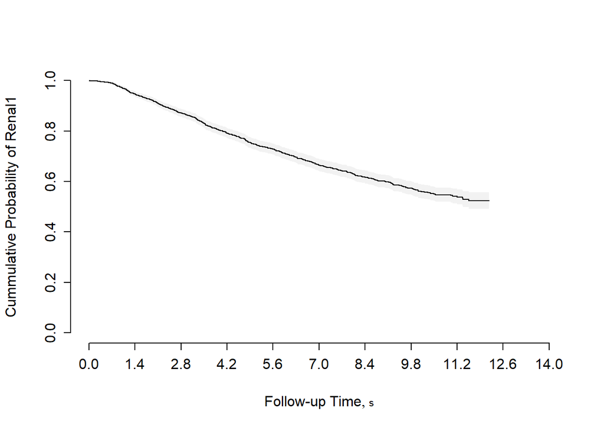

```r
km1 <- npsurv(Surv(my.data$time_renal1,my.data$renal1=="Yes") ~ 1, data = my.data)
survplot(km1,conf.int=0.95,conf="diffbands",ylab="Cummulative Probability of Renal1")
```

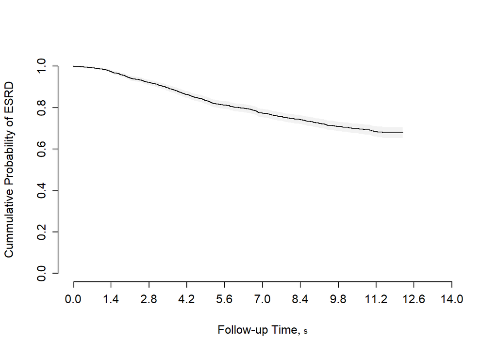

```r
km2 <- npsurv(Surv(my.data$time_esrd, my.data$esrd=="Yes") ~ 1, data = my.data)
survplot(km2,conf.int=0.95,conf="diffbands",ylab="Cummulative Probability of ESRD")
```

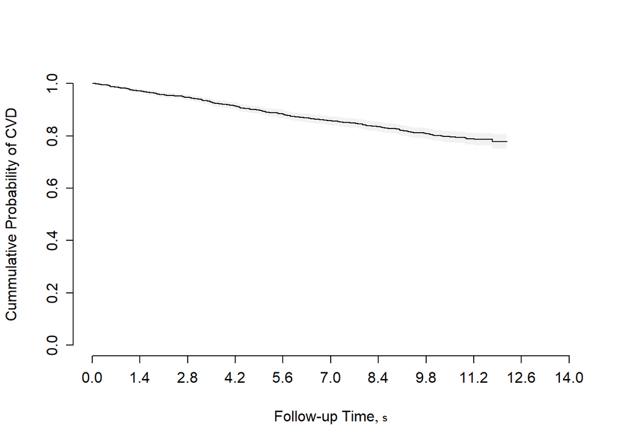

```r
km3<- npsurv(Surv(my.data$time_cvd, my.data$cvd=="Yes") ~ 1, data = my.data)
survplot(km3,conf.int=0.95,conf="diffbands",ylab="Cummulative Probability of CVD")
```

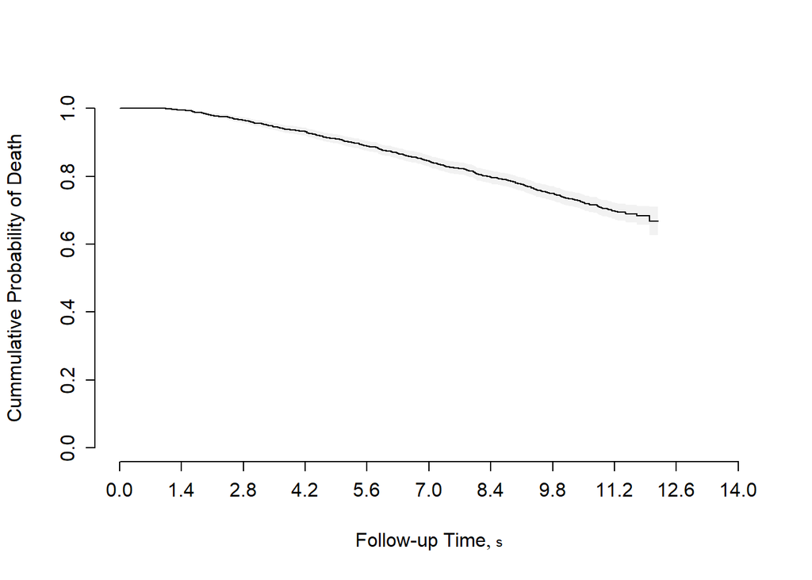

```r
km4<- npsurv(Surv(my.data$time_death, my.data$death=="Yes") ~ 1, data = my.data)
survplot(km4,conf.int=0.95,conf="diffbands",ylab="Cummulative Probability of Death")
```

##### Transform all variables to numeric, scale the dataset

```r
X <-  my.data[,c(2:11, 15:19)]
X[11:15] <-sapply(X[11:15], as.numeric)

X$antidiabetes<- X$antidiabetes-1
X$acearb<- X$acearb-1
X$betablk<-X$betablk-1
X$cablk <- X$cablk-1
X$diuretic<-X$diuretic -1

X.scaled <- scale(X)
```

### Results

```
## end fraction
```

```
## clustered
```

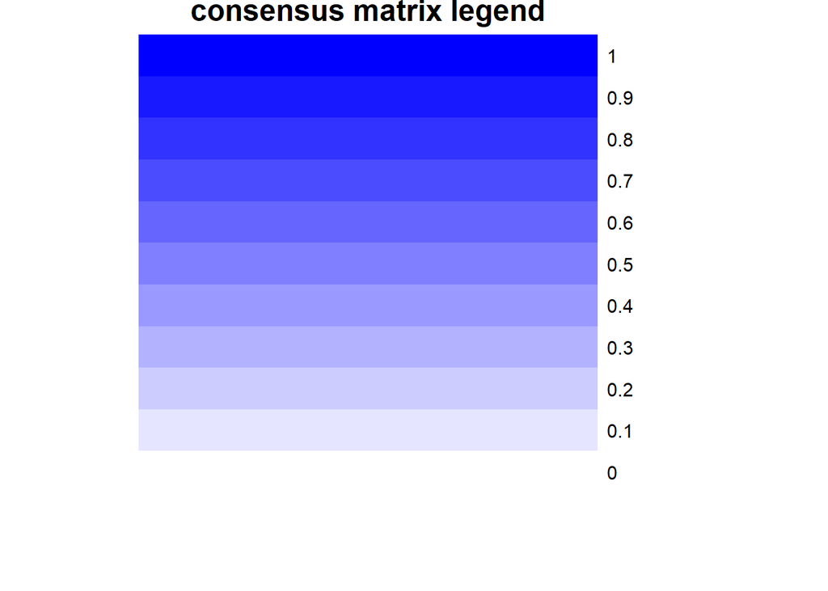

```
## clustered
```

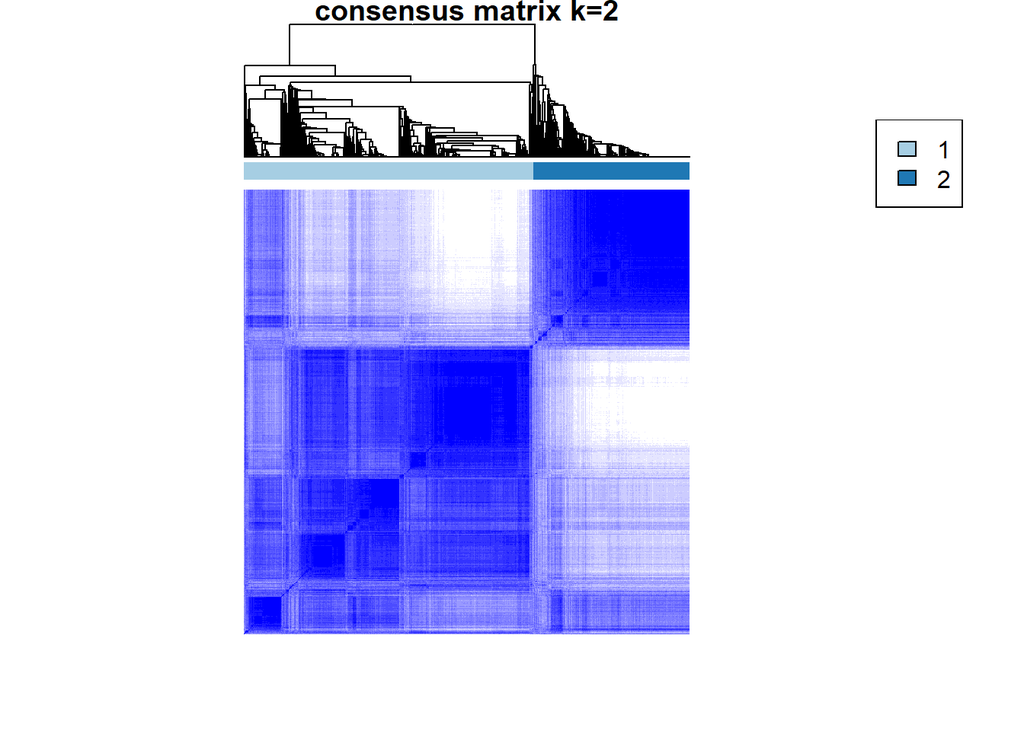

```
## clustered
```

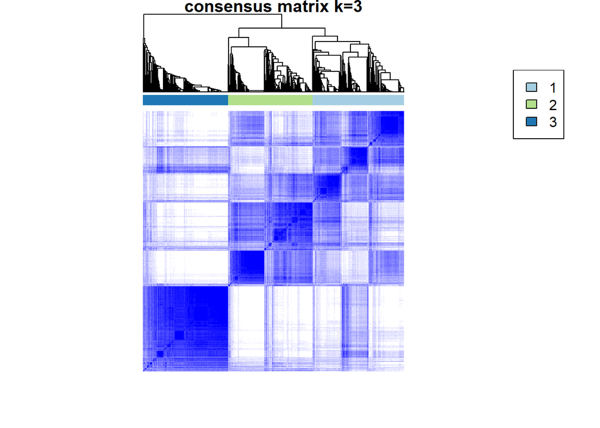

```
## clustered
```

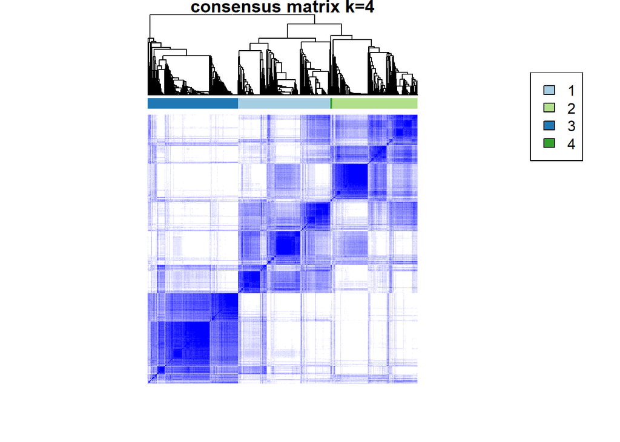

```
## clustered
```

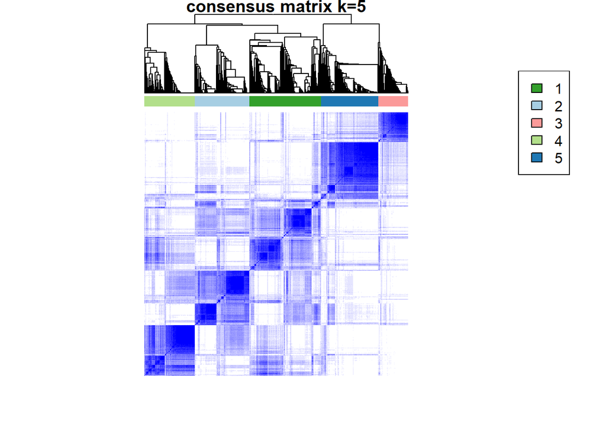

```
## clustered
```

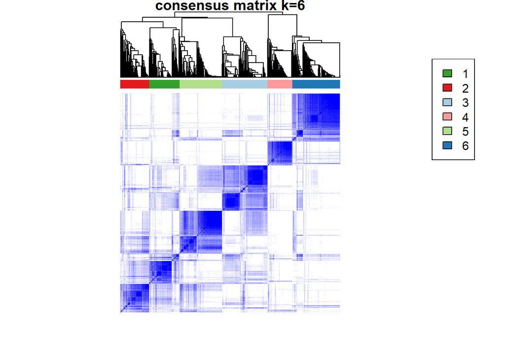

```
## clustered
```

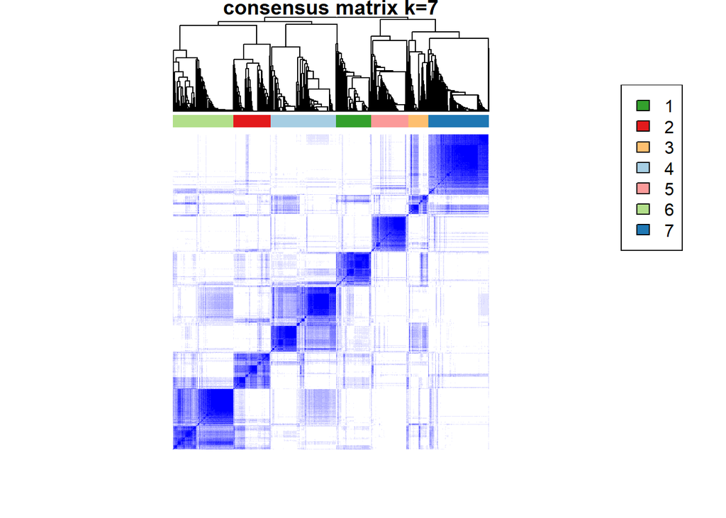

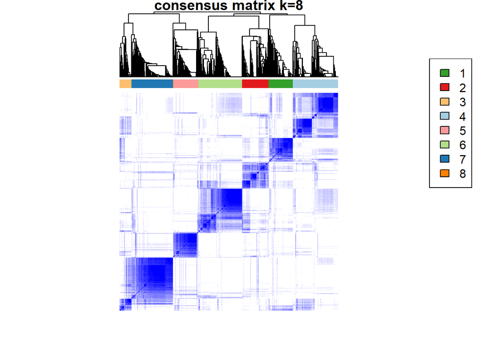

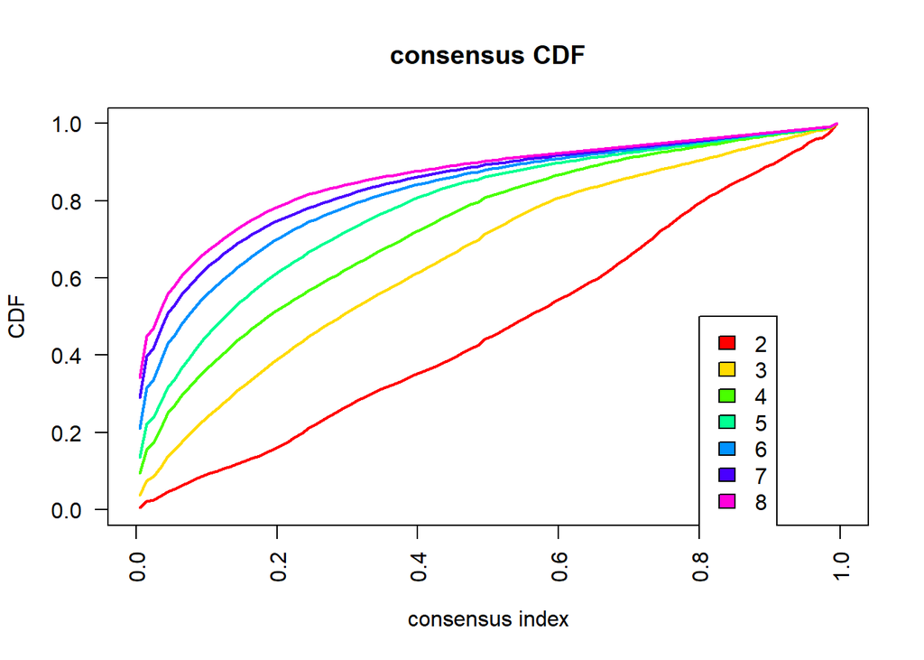

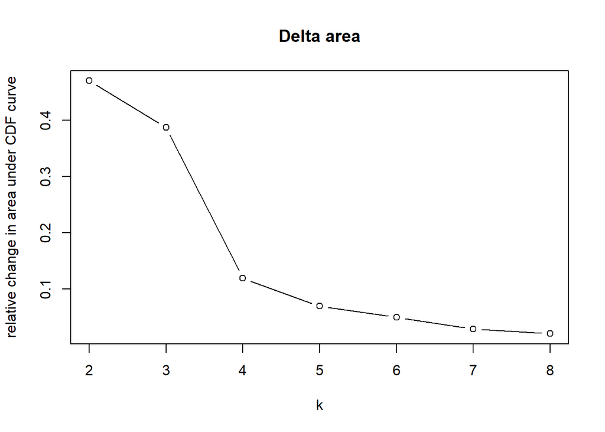

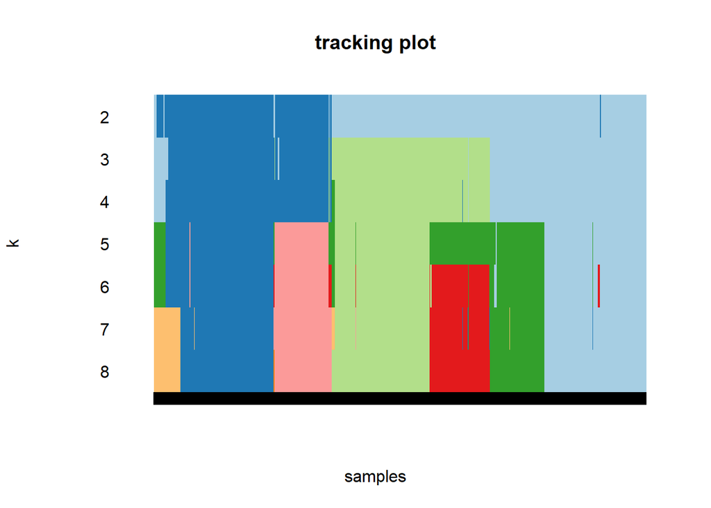

```r
# Consensus clustering
title <- paste0("C:/Users/zihez/Box Sync/DissertationResearch/DissertationAnalysis/Aim1/Output/CC/CC_plot_all")
rcc = ConsensusClusterPlus(t(X.scaled),maxK=8,reps=100,pItem=0.8,pFeature=1,title=title, distance="pearson",clusterAlg="hc",seed = 2659,plot=NULL)
```

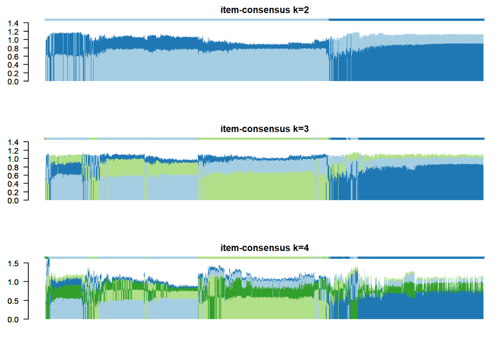

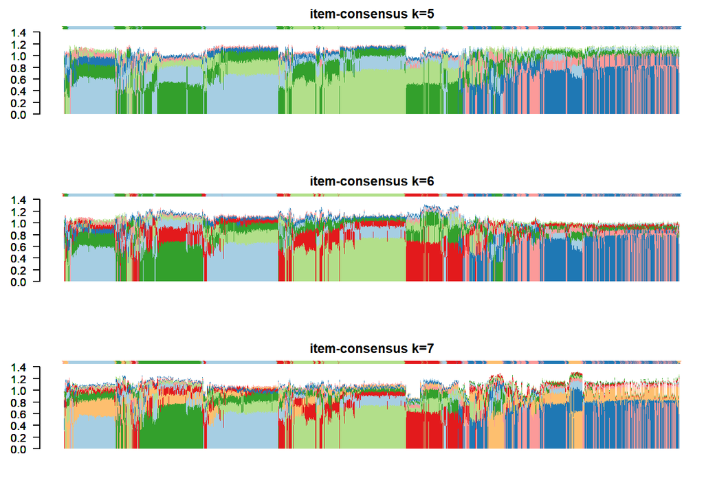

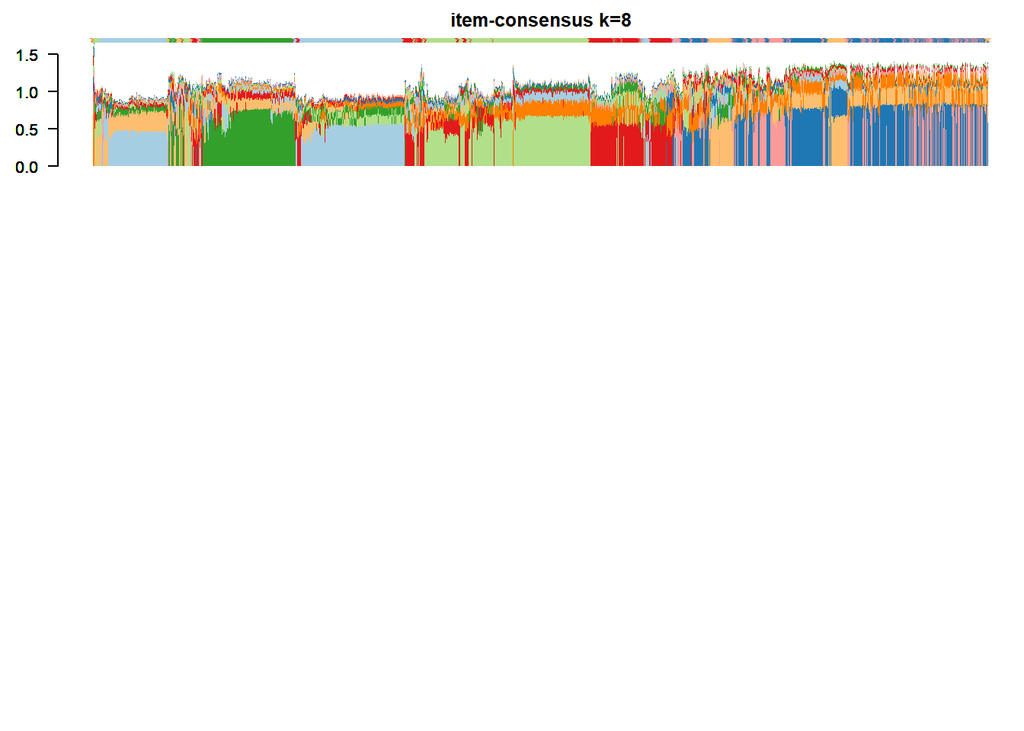

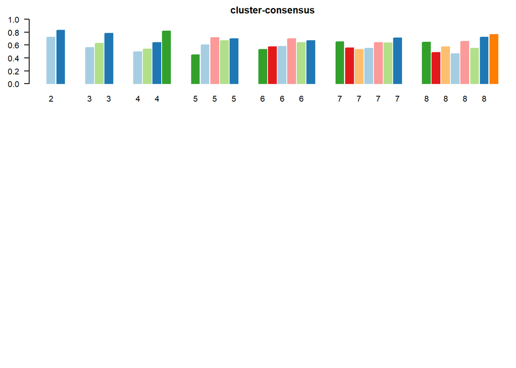

```r
icl = calcICL(rcc,title=title,plot=NULL)
```

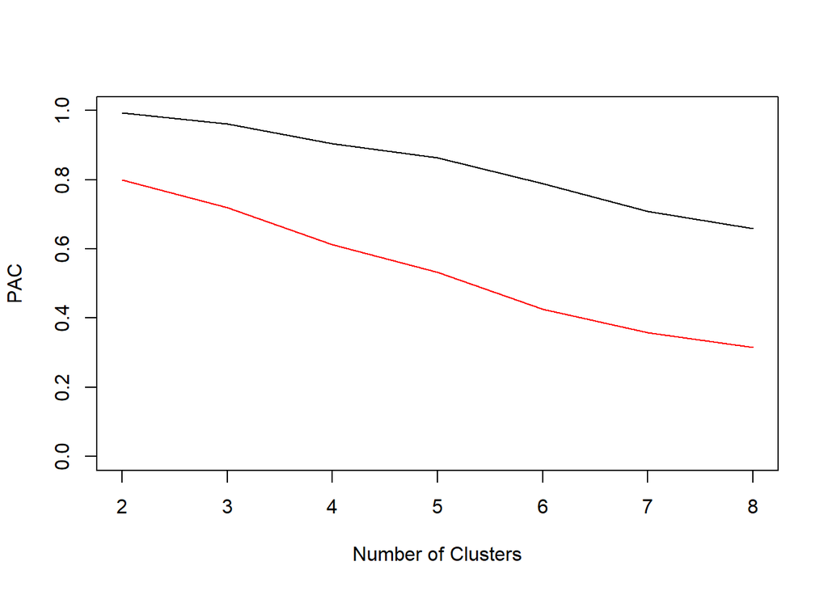

```r
Kvec = 2:8
PAC1 = rep(NA,length(Kvec))
PAC2 = rep(NA,length(Kvec))
names(PAC1) = paste("K=",Kvec,sep="") # from 2 to maxK
names(PAC2) = paste("K=",Kvec,sep="") # from 2 to maxK

for(i in Kvec){
  M = rcc[[i]]$consensusMatrix
  Fn = ecdf(M[lower.tri(M)])
  PAC1[i-1] = Fn(1) - Fn(0)
  PAC2[i-1] = Fn(0.9) - Fn(0.1)
}#end for i

plot(Kvec,PAC1,type='l',ylim=c(0,1),xlab="Number of Clusters",ylab="PAC")
lines(Kvec,PAC2,col=2)
```

```r
setwd("C:/Users/zihez/Box Sync/DissertationResearch/CRIC metabolomics")
save(rcc, file="./Data/R/list_rcc.RData")
save(icl, file="./Data/R/list_icl.RData")
```